# Automated String Clean Up

```r
library(PhyInsight)
```

## Introduction

The `rmBadStrings` functions (`rmBadStrings_1()`, `rmBadStrings_2()`, and `rmBadStrings_3()`) can be used to automatically clean a DNA string set that would otherwise be unsuitable for analysis. These functions use slightly different methods to automatically remove strings that are mismatched with others and those whose distances return `NaN` values or are considered outliers.

## Subset Data

```r
# query the data using the taxon name
specdata <- querySpecData("Nepenthes")

# subset results that only have nucleotides from the matK region
specdata <- subset(specdata, markercode == "matK")

# get one observation per species
specdata <- getSpeciesRepr(specdata)
```

## Manipulate DNA Strings

```r
# generate a DNA bin
DNABin <- genDNABin(specdata)

# use the DNA bin to create a DNA string set
DNAStringset <- genDNAStringSet(DNABin)

# automatically manipulate the DNA strings
DNAStringSet_manip <- ManipStringSet(DNAStringset)
```

## String Clean Up

At this point attempting to create a phylo tree will result in an error. Using `DECIPHER::BrowseSeqs(DNAStringSet_manip)` to view the string set will reveal a series of mismatched and fragmented strings. Using `rmBadStrings_1()` will automatically remove all mismatched strings. After which, a tree can be created and and plotted.

```r
# use the function to remove unsuitable strings and store into an object
BadStringsRemoved <- rmBadStrings_1(
  DNAStringSet = DNAStringSet_manip,
  specimen_dataframe = specdata
)
```

## Store New Objects

```r
DNAStringSet_new <- BadStringsRemoved[[1]]
specdata_new <- BadStringsRemoved[[2]]
```

## Create Phylogenetic Tree

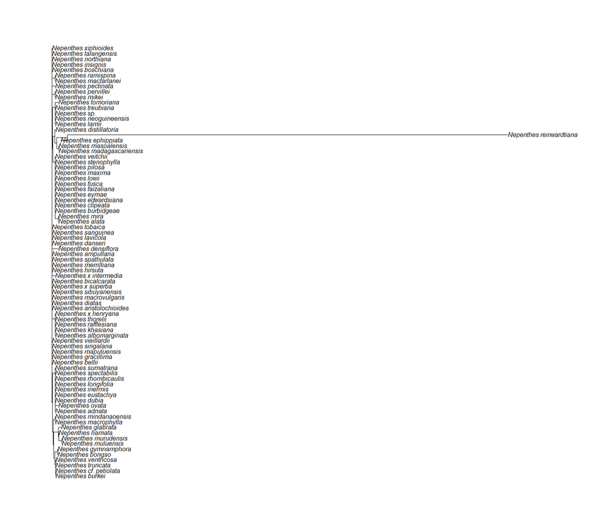

```r
# automatically generate a phylo tree
PhyloTree <- genPhytree(DNAStringSet_new)

# change the label names
PhyloTree$tip.label <- specdata_new$species_name

# plot the phylo tree
plot(
  PhyloTree,
  label.offset = 0.0001,
  cex = 1
)
```

# Remove Outliers

The `rmBadStrings` functions also have optional arguments to remove strings whose DNA distances are considered outliers. `rmOutliers` is a logical argument that when set to `TRUE` will automatically remove outliers as well as performing its regular processes. `max_Z_score` is a numerical value that allows the user to change the maximum Z score for each string’s DNA distance. The default value for this argument is 3 as a score higher than this is generally considered an outlier.

## Remove Outliers (Below 3 Z-Score)

```r
# use the function to remove unsuitable strings and remove outliers
BadStringsRemoved <- rmBadStrings_1(
  DNAStringSet = DNAStringSet_manip,
  specimen_dataframe = specdata,

  rmOutliers = TRUE
)
```

```
#> [1] "Outlier strings detected and removed:  58"
```

## Store New Objects

```r
DNAStringSet_new <- BadStringsRemoved[[1]]
specdata_new <- BadStringsRemoved[[2]]
```

## Create Phylogenetic Tree

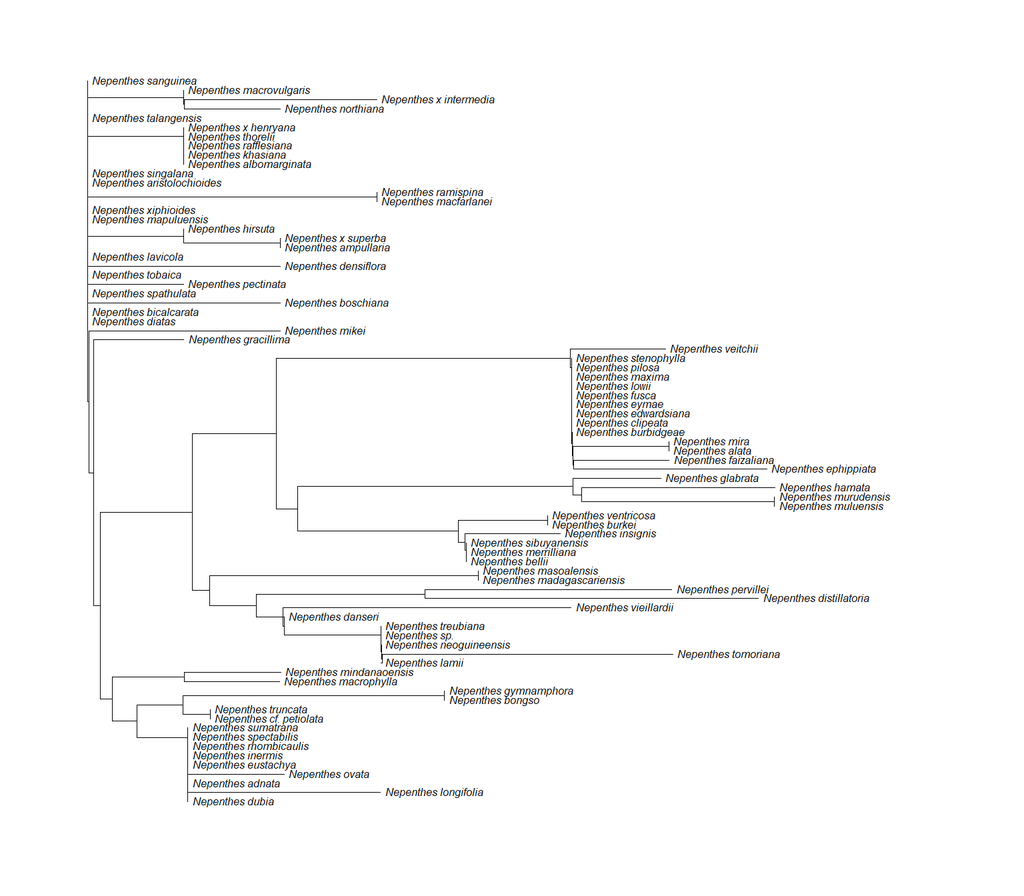

```r
# automatically generate a phylo tree
PhyloTree <- genPhytree(DNAStringSet_new)

# change the label names
PhyloTree$tip.label <- specdata_new$species_name

# plot the phylo tree
plot(
  PhyloTree,
  label.offset = 0.0001,
  cex = 1
)
```

## Remove Outliers (Below 2 Z-Score)

```r
# use the function to remove unsuitable strings and remove outliers
BadStringsRemoved <- rmBadStrings_1(
  DNAStringSet = DNAStringSet_manip,
  specimen_dataframe = specdata,

  rmOutliers = TRUE,

  max_Z_score = 2
)
```

```
#> [1] "Outlier strings detected and removed:  58"
#> [1] "Outlier strings detected and removed:  8"
#> [2] "Outlier strings detected and removed:  17"
#> [3] "Outlier strings detected and removed:  20"
#> [4] "Outlier strings detected and removed:  27"
#> [5] "Outlier strings detected and removed:  28"
#> [6] "Outlier strings detected and removed:  48"
#> [7] "Outlier strings detected and removed:  49"
#> [8] "Outlier strings detected and removed:  54"
#> [9] "Outlier strings detected and removed:  70"
#>  [1] "Outlier strings detected and removed:  2"
#>  [2] "Outlier strings detected and removed:  20"
#>  [3] "Outlier strings detected and removed:  22"
#>  [4] "Outlier strings detected and removed:  30"
#>  [5] "Outlier strings detected and removed:  32"
```

[output cut: 21 more lines]

## Store New Objects

```r
DNAStringSet_new <- BadStringsRemoved[[1]]
specdata_new <- BadStringsRemoved[[2]]
```

## Create Phylogenetic Tree

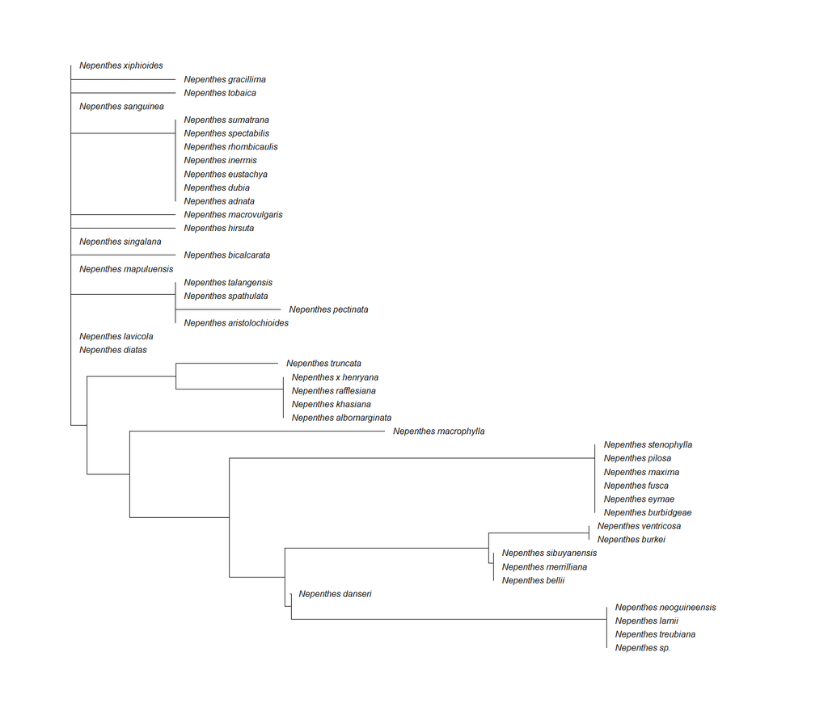

```r
# automatically generate a phylo tree
PhyloTree <- genPhytree(DNAStringSet_new)

# change the label names
PhyloTree$tip.label <- specdata_new$species_name

# plot the phylo tree
plot(
  PhyloTree,
  label.offset = 0.0001,
  cex = 1
)
```